# Predicting the Default of Credit Card Clients

2024-04-11

## Univariate Analysis:

### Qantitative DATA

```r
summary(UCI_Credit_Card[col_names_Quanti])
```

```
##    LIMIT_BAL            AGE          BILL_AMT1         BILL_AMT2
##  Min.   :  10000   Min.   :21.00   Min.   :-165580   Min.   :-69777
##  1st Qu.:  50000   1st Qu.:28.00   1st Qu.:   3559   1st Qu.:  2985
##  Median : 140000   Median :34.00   Median :  22382   Median : 21200
##  Mean   : 167484   Mean   :35.49   Mean   :  51223   Mean   : 49179
##  3rd Qu.: 240000   3rd Qu.:41.00   3rd Qu.:  67091   3rd Qu.: 64006
##  Max.   :1000000   Max.   :79.00   Max.   : 964511   Max.   :983931
##    BILL_AMT3         BILL_AMT4         BILL_AMT5        BILL_AMT6
##  Min.   :-157264   Min.   :-170000   Min.   :-81334   Min.   :-339603
##  1st Qu.:   2666   1st Qu.:   2327   1st Qu.:  1763   1st Qu.:   1256
##  Median :  20089   Median :  19052   Median : 18105   Median :  17071
##  Mean   :  47013   Mean   :  43263   Mean   : 40311   Mean   :  38872
##  3rd Qu.:  60165   3rd Qu.:  54506   3rd Qu.: 50191   3rd Qu.:  49198
##  Max.   :1664089   Max.   : 891586   Max.   :927171   Max.   : 961664
##     PAY_AMT1         PAY_AMT2          PAY_AMT3         PAY_AMT4
##  Min.   :     0   Min.   :      0   Min.   :     0   Min.   :     0
##  1st Qu.:  1000   1st Qu.:    833   1st Qu.:   390   1st Qu.:   296
##  Median :  2100   Median :   2009   Median :  1800   Median :  1500
##  Mean   :  5664   Mean   :   5921   Mean   :  5226   Mean   :  4826
##  3rd Qu.:  5006   3rd Qu.:   5000   3rd Qu.:  4505   3rd Qu.:  4013
##  Max.   :873552   Max.   :1684259   Max.   :896040   Max.   :621000
##     PAY_AMT5           PAY_AMT6
##  Min.   :     0.0   Min.   :     0.0
##  1st Qu.:   252.5   1st Qu.:   117.8
##  Median :  1500.0   Median :  1500.0
##  Mean   :  4799.4   Mean   :  5215.5
##  3rd Qu.:  4031.5   3rd Qu.:  4000.0
##  Max.   :426529.0   Max.   :528666.0
```

> We have:  
> - Negative BILL_AMT ? We should investigate that .

### Analysing LIMIT_BAL using histogram

```r
gg <- ggplot(UCI_Credit_Card, aes(x = LIMIT_BAL, fill = Payment_Status)) +
  geom_histogram( color = "black") +
  labs(title = "Distribution of LIMIT_BAL by Payment_Status",
       x = "LIMIT_BAL",
       y = "Count",
       fill = "Payment_Status") +
  theme_minimal()+
  theme(plot.background = element_rect(fill = "#fffff8"))


ggplotly(gg)
```

[interactive chart not shown]

> 50k is the most frequent LIMIT_BAL

### Checking LIMIT_BAL Distribution unsing Q-Q plot

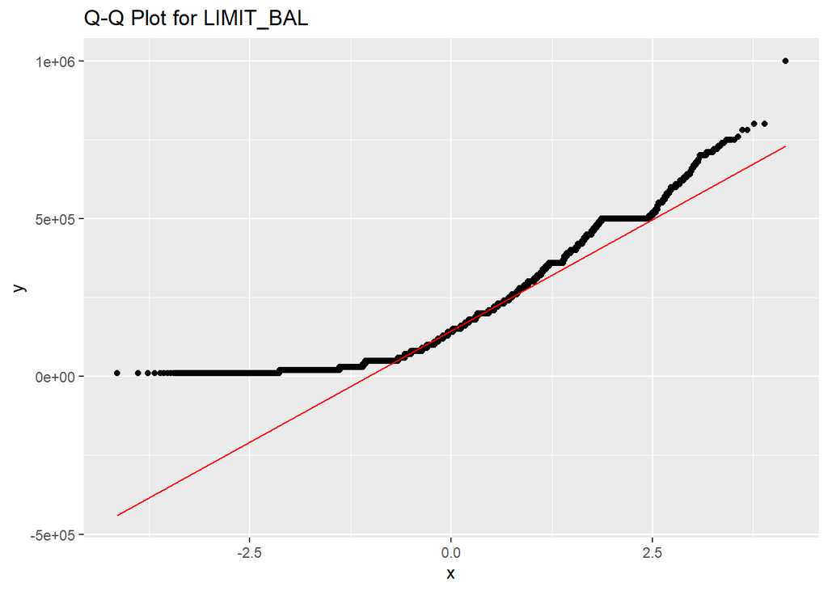

```r
ggplot(data = UCI_Credit_Card, aes(sample = LIMIT_BAL)) +
  stat_qq() +
  stat_qq_line(col = "red") +
  labs(title = "Q-Q Plot for LIMIT_BAL")
```

> Asymmetrical Distribution (positively skewed)

### Analysing AGE using histogram

```r
gg <- ggplot(UCI_Credit_Card, aes(x = AGE, fill = Payment_Status)) +
  geom_histogram( color = "black") +
  labs(title = "Distribution of AGE by Payment_Status",
       x = "AGE",
       y = "Count",
       fill = "Payment_Status") +
  theme_minimal()+
  theme(plot.background = element_rect(fill = "#fffff8"))


ggplotly(gg)
```

[interactive chart not shown]

> The most frequent AGE is 29.

### Checking AGEL Distribution unsing Q-Q plot

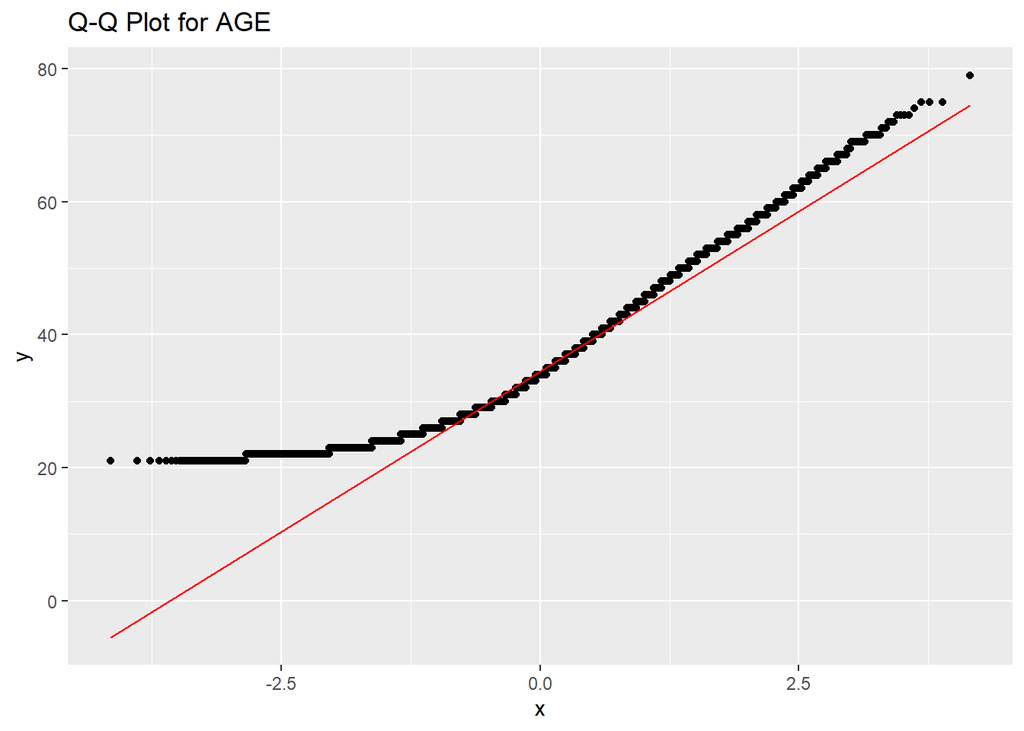

```r
ggplot(data = UCI_Credit_Card, aes(sample = AGE)) +
  stat_qq() +
  stat_qq_line(col = "red") +
  labs(title = "Q-Q Plot for AGE")
```

> Asymmetrical Distribution (positively skewed).

### Analysing BILL_AMT(i) using histogram

```r
BILL_AMT_LIST<-list("BILL_AMT1","BILL_AMT2","BILL_AMT3","BILL_AMT4","BILL_AMT5","BILL_AMT6")
histogram_list <- lapply(BILL_AMT_LIST, function(col_name) {
    plot_ly(UCI_Credit_Card, x = ~get(col_name), type = "histogram", histnorm = "probability density",nbinsx = 80,name = col_name) %>%
      layout(title = "Histograms of Bill Amounts")
  })
  combined_plot <- subplot(histogram_list, nrows = 3)
  combined_plot
```

[interactive chart not shown]

> We can’t see much from those plots

### Using Q_Q plot to check the distrubution

#### 1.BILL_AMT1

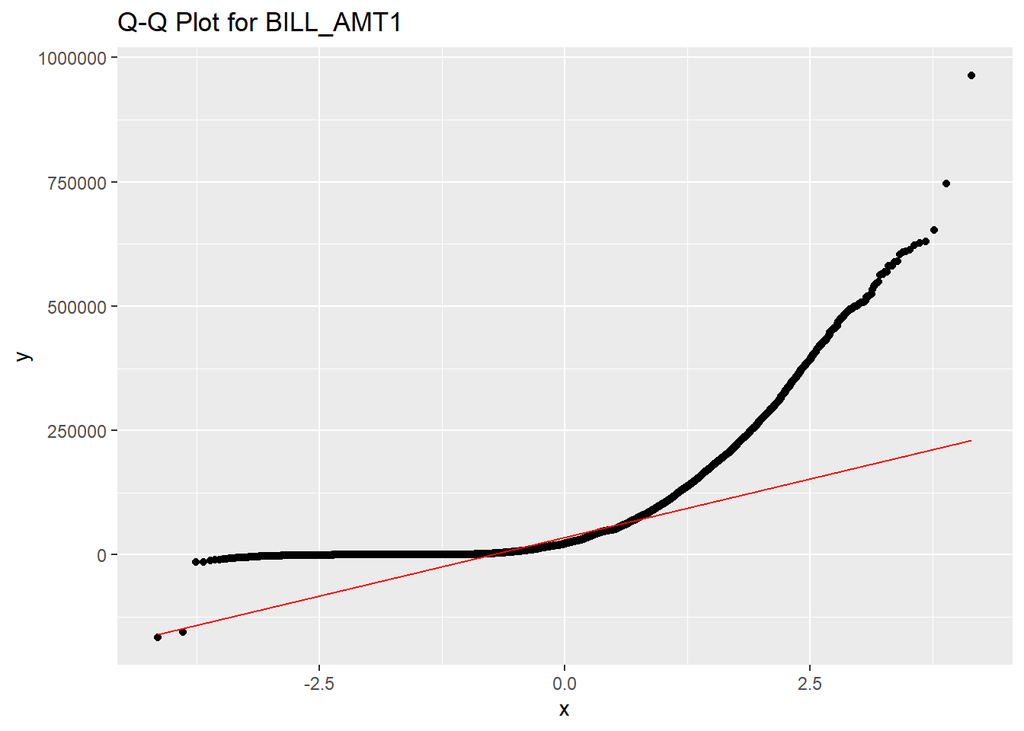

```r
ggplot(data = UCI_Credit_Card, aes(sample = BILL_AMT1)) +
  stat_qq() +
  stat_qq_line(col = "red") +
  labs(title = "Q-Q Plot for BILL_AMT1")
```

#### 2.BILL_AMT2

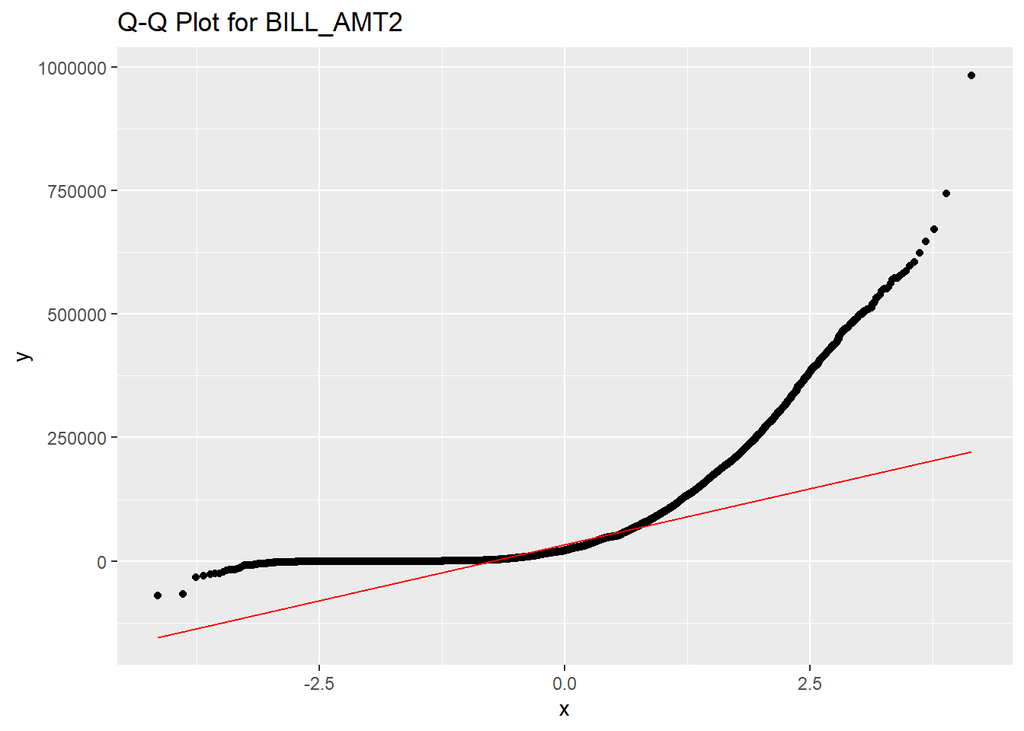

```r
ggplot(data = UCI_Credit_Card, aes(sample = BILL_AMT2)) +
  stat_qq() +
  stat_qq_line(col = "red") +
  labs(title = "Q-Q Plot for BILL_AMT2")
```

#### 3.BILL_AMT3

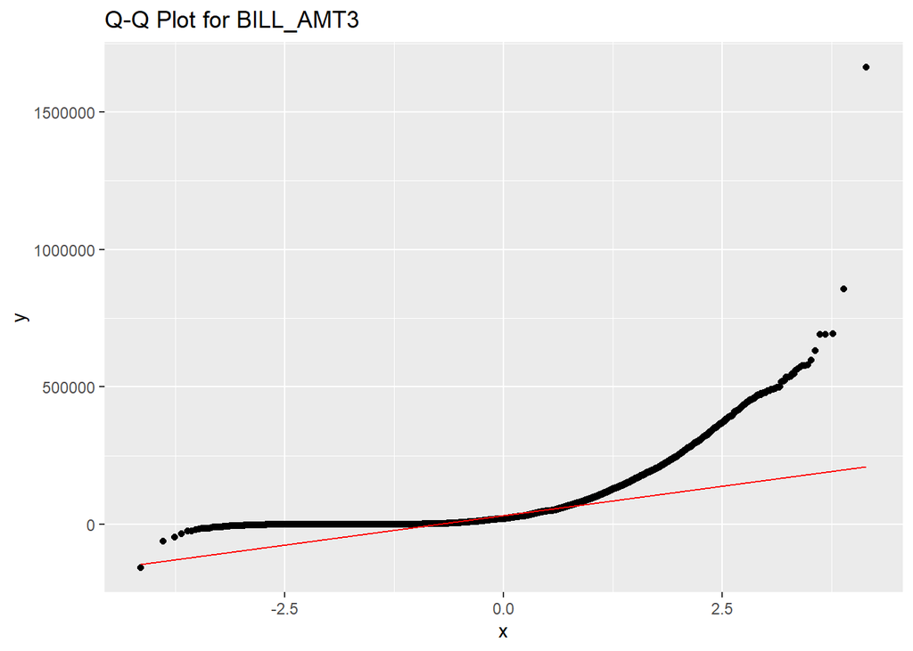

```r
ggplot(data = UCI_Credit_Card, aes(sample = BILL_AMT3)) +
  stat_qq() +
  stat_qq_line(col = "red") +
  labs(title = "Q-Q Plot for BILL_AMT3")
```

#### 4.BILL_AMT4

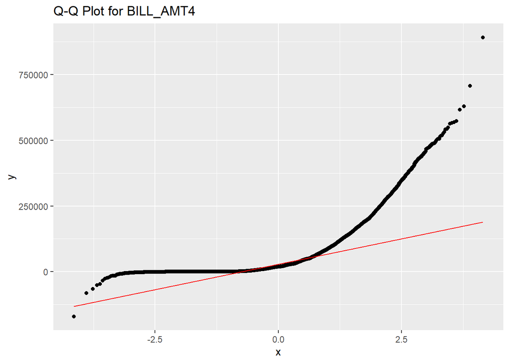

```r
ggplot(data = UCI_Credit_Card, aes(sample = BILL_AMT4)) +
  stat_qq() +
  stat_qq_line(col = "red") +
  labs(title = "Q-Q Plot for BILL_AMT4")
```

#### 5.BILL_AMT5

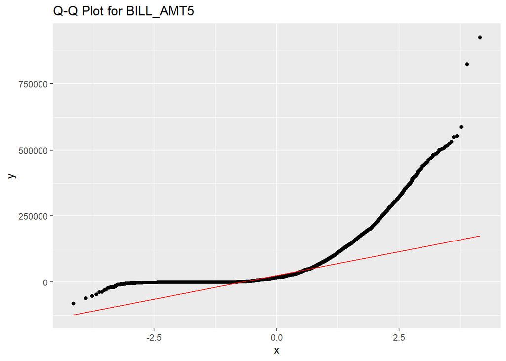

```r
ggplot(data = UCI_Credit_Card, aes(sample = BILL_AMT5)) +
  stat_qq() +
  stat_qq_line(col = "red") +
  labs(title = "Q-Q Plot for BILL_AMT5")
```

#### 6.BILL_AMT6

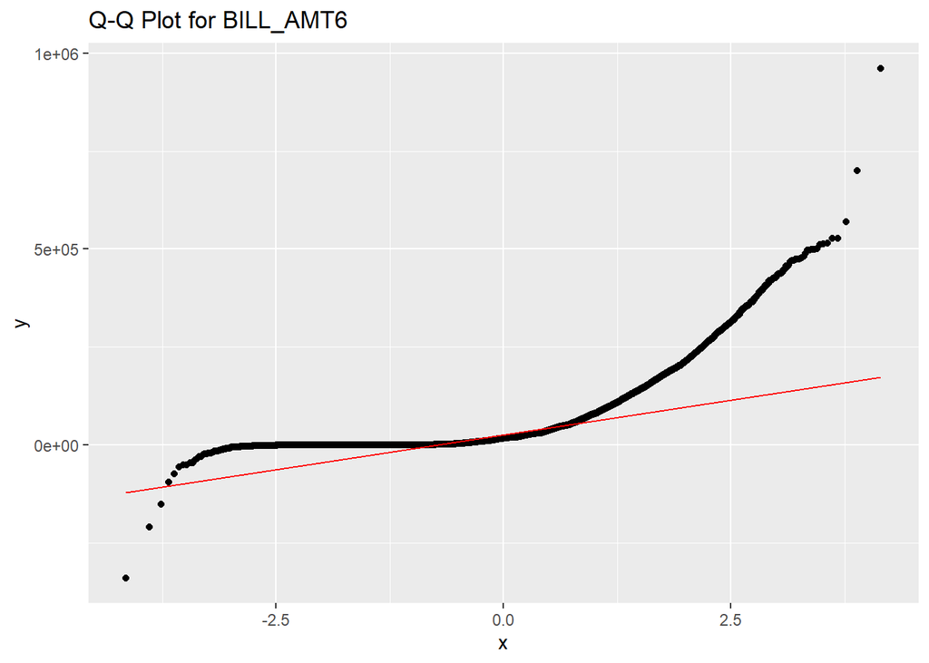

```r
ggplot(data = UCI_Credit_Card, aes(sample = BILL_AMT6)) +
  stat_qq() +
  stat_qq_line(col = "red") +
  labs(title = "Q-Q Plot for BILL_AMT6")
```

> The distribution of variables can influence both the correlation between variables and the choice of model used for analysis.

BILL_AMT(i) :Amount of bill statement in month (i), 2005 (NT dollar) .So ,what does negative value mean

```r
negative_BILL_AMT<-UCI_Credit_Card %>%
  filter(BILL_AMT1 < 0 | BILL_AMT2 < 0 | BILL_AMT3 < 0 | BILL_AMT4 < 0 | BILL_AMT5 < 0 | BILL_AMT6 < 0)
head(negative_BILL_AMT)
```

```
##   LIMIT_BAL SEX EDUCATION MARRIAGE AGE PAY_1 PAY_2 PAY_3 PAY_4 PAY_5 PAY_6
## 1    100000   2         2        2  23     0    -1    -1     0     0    -1
## 2     60000   1         1        2  27     1    -2    -1    -1    -1    -1
## 3    160000   1         1        2  30    -1    -1    -2    -2    -2    -1
## 4     60000   2         2        2  22     0     0     0     0     0    -1
## 5    180000   2         3        1  34     0     0     0    -1    -1    -1
## 6    130000   2         3        2  29     1    -2    -2    -1     2    -1
##   BILL_AMT1 BILL_AMT2 BILL_AMT3 BILL_AMT4 BILL_AMT5 BILL_AMT6 PAY_AMT1 PAY_AMT2
## 1     11876       380       601       221      -159       567      380      601
## 2      -109      -425       259       -57       127      -189        0     1000
## 3     30265      -131      -527      -923     -1488     -1884      131      396
## 4     15054      9806     11068      6026    -28335     18660     1500     1518
## 5     16386     15793      8441      7142      -679      8321     8500     1500
## 6      -190     -9850     -9850     10311     10161      7319        0        0
##   PAY_AMT3 PAY_AMT4 PAY_AMT5 PAY_AMT6 Payment_Status
## 1        0      581     1687     1542              0
## 2        0      500        0     1000              1
## 3      396      565      792        0              0
## 4     2043        0    47671      617              0
## 5     7500      679     9000     2000              0
## 6    20161        0     7319    13899              0
```

> Hypothesis: It may imply that the bank owes them money, as they are making payments exceeding what is expected.

### Using histogram visualisation for “PAY_AMT(i)”

```r
PAY_AMT_list<-c("PAY_AMT1","PAY_AMT2","PAY_AMT3","PAY_AMT4","PAY_AMT5","PAY_AMT6")

histogram_list <- lapply(PAY_AMT_list, function(col_name) {
    plot_ly(UCI_Credit_Card, x = ~get(col_name), type = "histogram",nbinsx = 70 ,name = col_name) %>%
      layout(title ="Histograms of Pay Amounts")
  })
  combined_plot <- subplot(histogram_list, nrows = 3)
  combined_plot
```

[interactive chart not shown]

> The distribution of PAY_AMT is heavily skewed and violates the assumption of normality. > We can consider applying a log transformation to the data to make the distribution more symmetric.

```r
# Define a small constant to add to the variable
epsilon <- 1e-10


histogram_list <- lapply(PAY_AMT_list, function(col_name) {
    plot_ly(UCI_Credit_Card, x = ~log(get(col_name) + epsilon), type = "histogram", nbinsx = 70 , name = col_name) %>%
      layout(title = "Histograms of Pay Amounts")
})


combined_plot <- subplot(histogram_list, nrows = 3)
combined_plot
```

[interactive chart not shown]

### Catagorical DATA

```r
summary(UCI_Credit_Card[col_names_Cato])
```

```
##  SEX       EDUCATION MARRIAGE      PAY_1           PAY_2           PAY_3
##  1:11888   0:   14   0:   54   0      :14737   0      :15730   0      :15764
##  2:18112   1:10585   1:13659   -1     : 5686   -1     : 6050   -1     : 5938
##            2:14030   2:15964   1      : 3688   2      : 3927   -2     : 4085
##            3: 4917   3:  323   -2     : 2759   -2     : 3782   2      : 3819
##            4:  123             2      : 2667   3      :  326   3      :  240
##            5:  280             3      :  322   4      :   99   4      :   76
##            6:   51             (Other):  141   (Other):   86   (Other):   78
##      PAY_4           PAY_5           PAY_6       Payment_Status
##  0      :16455   0      :16947   0      :16286   0:23364
##  -1     : 5687   -1     : 5539   -1     : 5740   1: 6636
##  -2     : 4348   -2     : 4546   -2     : 4895
##  2      : 3159   2      : 2626   2      : 2766
##  3      :  180   3      :  178   3      :  184
##  4      :   69   4      :   84   4      :   49
##  (Other):  102   (Other):   80   (Other):   80
```

### Using Pie Chart for SEX

```r
SEX_counts <- table(UCI_Credit_Card$SEX)

plot_ly(labels = c("Male", "Female"), values = SEX_counts, type = 'pie') %>%
  layout(annotations = list(
      x = 0,
      y = 1,
      xref = "paper",
      yref = "paper",
      text = "Pie Chart for SEX",
      font = list(color = "black", size = 20),
      showarrow = FALSE),piecolorway = c( "pink","blue"))
```

[interactive chart not shown]

> We have more than half female

### Using Pie Chart for EDUCATION

```r
EDUCATION_counts <- table(UCI_Credit_Card$EDUCATION)
EDUCATION_counts
```

```
##
##     0     1     2     3     4     5     6
##    14 10585 14030  4917   123   280    51
```

```r
plot_ly(labels = list("unlabel","graduate school","university", "high school", "others", "unknown", "unknown"), values = EDUCATION_counts, type = 'pie') %>%
  layout(annotations = list(
      x = 0,
      y = 1,
      xref = "paper",
      yref = "paper",
      text = "Pie Chart for EDUCATION",
      font = list(color = "black", size = 15),
      showarrow = FALSE))
```

[interactive chart not shown]

### Using Pie Chart for MARRIAGE

```r
MARRIAGE_counts <- table(UCI_Credit_Card$MARRIAGE)
MARRIAGE_counts
```

```
##
##     0     1     2     3
##    54 13659 15964   323
```

```r
plot_ly(labels = c("unlabel","married", "single", "others"), values = MARRIAGE_counts, type = 'pie') %>%
  layout(annotations = list(
      x = 0,
      y = 1,
      xref = "paper",
      yref = "paper",
      text = "Pie Chart for MARRIAGE",
      font = list(color = "black", size = 15),
      showarrow = FALSE))
```

[interactive chart not shown]

```r
labels_PAY <- c("-2" = "unlabel(-2)", "-1" = "pay duly", "0" = "unlabel(0)",
                  "1" = "pay_del_1_mth", "2" = "pay_del_2_mths",
                  "3" = "pay_del_3_mths", "4" = "pay_del_4_mths",
                  "5" = "pay_del_5_mths", "6" = "pay_del_6_mths",
                  "7" = "pay_del_7_mths", "8" = "pay_del_8_mths",
                  "9" = "pay_del_9_mths_above")
ggplotly(
ggplot(UCI_Credit_Card, aes(x = PAY_1, fill = PAY_1)) +
  geom_bar() +
  labs(title = "Bar Plot by PAY_1", y = "Frequency") +
  theme_classic() +
  scale_x_discrete(labels = labels_PAY)+theme(axis.text.x = element_text(angle = 45, hjust = 1))
)
```

[interactive chart not shown]

> unlabel(0) is the most frequent category

### Using barplot for “PAY_2”

```r
ggplotly(
ggplot(UCI_Credit_Card, aes(x = PAY_2, fill = PAY_2)) +
  geom_bar() +
  labs(title = "Bar Plot by PAY_2", y = "Frequency") +
  theme_classic() +
  scale_x_discrete(labels = labels_PAY)+theme(axis.text.x = element_text(angle = 45, hjust = 1))
)
```

[interactive chart not shown]

> unlabel(0) is the most frequent category

### Using barplot for “PAY_3”

```r
ggplotly(
ggplot(UCI_Credit_Card, aes(x = PAY_3, fill = PAY_3)) +
  geom_bar() +
  labs(title = "Bar Plot by PAY_3", y = "Frequency") +
  theme_classic() +
  scale_x_discrete(labels = labels_PAY)+theme(axis.text.x = element_text(angle = 45, hjust = 1))
)
```

[interactive chart not shown]

> unlabel(0) is the most frequent category

### Using barplot for “PAY_4”

```r
ggplotly(
ggplot(UCI_Credit_Card, aes(x = PAY_4, fill = PAY_4)) +
  geom_bar() +
  labs(title = "Bar Plot by PAY_4", y = "Frequency") +
  theme_classic() +
  scale_x_discrete(labels = labels_PAY)+theme(axis.text.x = element_text(angle = 45, hjust = 1))
)
```

[interactive chart not shown]

> unlabel(0) is the most frequent category

### Using barplot for “PAY_5”

```r
ggplotly(
ggplot(UCI_Credit_Card, aes(x = PAY_5, fill = PAY_5)) +
  geom_bar() +
  labs(title = "Bar Plot by PAY_5", y = "Frequency") +
  theme_classic() +
  scale_x_discrete(labels = labels_PAY)+theme(axis.text.x = element_text(angle = 45, hjust = 1))
)
```

[interactive chart not shown]

> unlabel(0) is the most frequent category

### Using barplot for “PAY_6”

```r
ggplotly(
ggplot(UCI_Credit_Card, aes(x = PAY_6, fill = PAY_6)) +
  geom_bar() +
  labs(title = "Bar Plot by PAY_6", y = "Frequency") +
  theme_classic() +
  scale_x_discrete(labels = labels_PAY)+theme(axis.text.x = element_text(angle = 45, hjust = 1))
)
```

[interactive chart not shown]

> unlabel(0) is the most frequent category

> > we should investigate unlabel(0)

### Using Charpie for Payment_Status :

```r
PayStatue_counts <- table(UCI_Credit_Card$Payment_Status)

plot_ly(labels = c("Non_default", "Default"), values = PayStatue_counts, type = 'pie') %>%
  layout(annotations = list(
      x = 0,
      y = 1,
      xref = "paper",
      yref = "paper",
      text = "Pie Chart for Payment_Status",
      font = list(color = "black", size = 14),
      showarrow = FALSE),piecolorway = c("lightgreen", "lightcoral"))
```

[interactive chart not shown]

> Nearly 80 % did not default